# R的练习之三

五月 14, 2017

#### 技术须知

- 完成此作业需要你使用rmarkdown，并编译生成html文件，html文件请用自己的学号命名（仅需要学号即可，不用写姓名）。
- 此作业所需的数据为**CEPS基线调查学生数据.sav**，问卷是**“九年级学生问卷.pdf”**和**“七年级学生问卷.pdf”“**，数据和问卷都在微云的共享文件夹里，微信群里发给大家。也可以点击如下[*链接*](http://url.cn/46mFZvi) 获取。
- 作业请邮件至hmmailbox@126.com，截止时间是5月24日上午12时。

#### 作业要求

##### 0. 这次作业的目的是练习直接在R里实现基于*回归分析*的数据分析报告，rmarkdown的使用请参考**“R_markdown.Rmd”**。

##### 1. 所有R代码请隐藏，报告中看不到R代码或R的运行结果。

##### 2. 篇幅不超过三页A4纸，可生成html文件后，试用打印机打印，看是否超过两页，但*不需要真的打印出纸版*。

##### 3. 请在**CEPS基线调查学生数据.sav**数据里挑选若干变量，形成一个小的主题，分析均围绕主题进行，比较聚焦。

##### 4. 请选择5-8个变量进回归分析（自变量中至少一个分类变量），注意报告规范。请在报告中包含以下内容：

- 4.1 是否线性关系，唯线性关系可使用线性回归模型；
- 4.2 残差是否正态和方差齐性，若非正态或不齐，考虑模型意义的情况下，确定是否需要进行BOX-COX变换；
- 4.3 是否存在高杠杆值、离群点和强影响点，删除至少一个强影响点后模型是否有变化；
- 4.4 建构简单模型和复杂模型，二者间有嵌套关系，检验两个模型间是否有显著差异。

##### 5. 报告格式：

- 5.1 4.1、4.2和4.3的报告请结合图形用文字加以描述；
- 5.2 4.3和4.4的报告请结合表格并加以文字描述，可参看下例：

> 线性回归分析显示，社会技能是攻击性得分的显著预测变量（b = .40, p = .008），可解释攻击行为16%的变异。

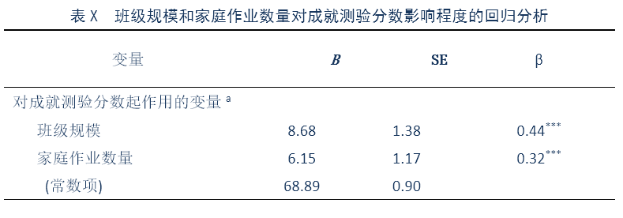

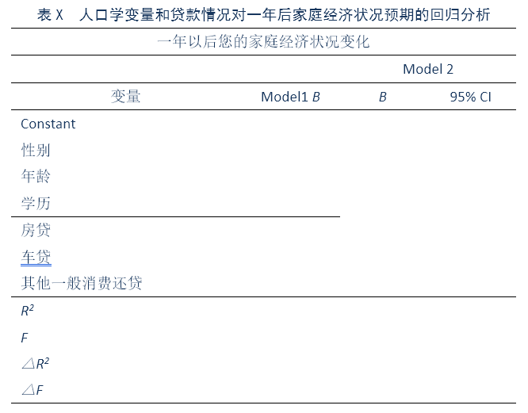